# Week 3 Peer Review

Following the directions on the Coursera assignment page, you will make four original visualizations. Note that the data for the CCES and CEL data are imported in code in the R Markdown file.

### Put your name here: WANG XIAOYUAN

## Exercise 1

Explain what you are visualizing here: the scatter plot of vote percentage won versus the seniority of MC for congress 115, I hypothesize that these two variables are positively correlated. I also use female variable to color the point and dem variable for facetting. Put your figure here:

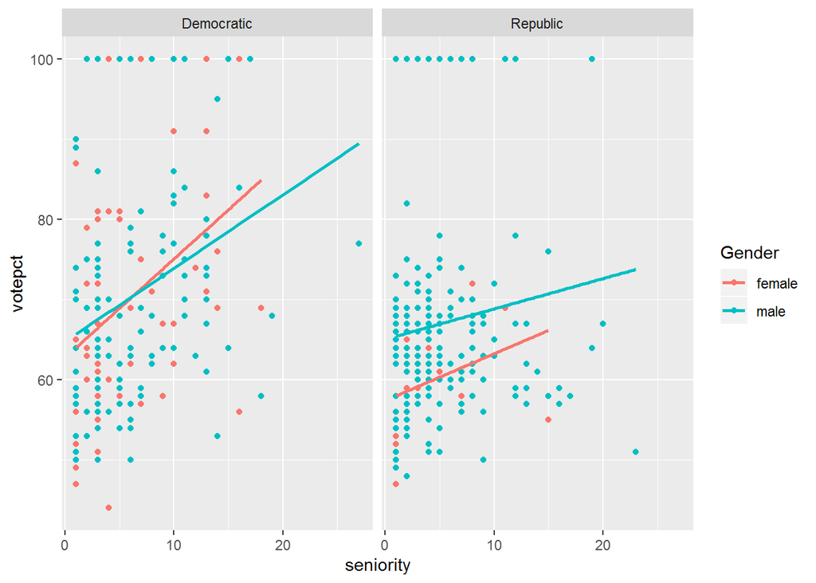

## Exercise 2

Explain what you are visualizing here: The boxplot of vote percentage won for each party in congress 115

Put your figure here:

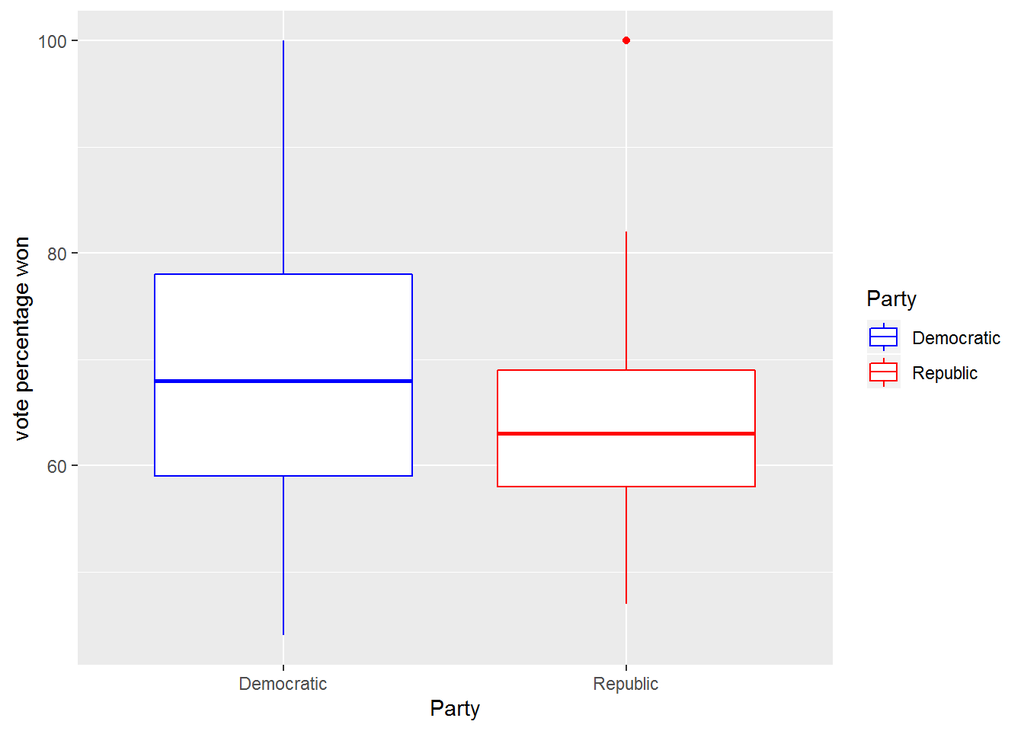

## Exercise 3

Explain what you are visualizing here: The number of male and female MC for each party for congress 115

Put your figure here:

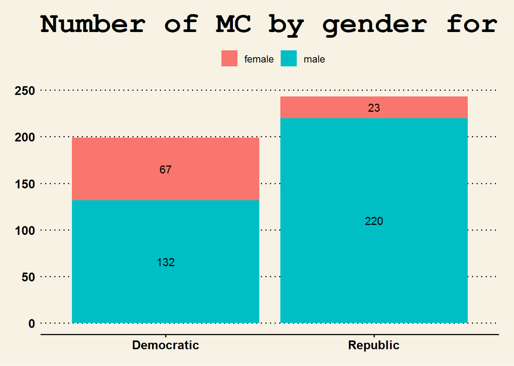

## Exercise 4

Explain what you are visualizing here: The number of MC from each party for all the congress, the x axis will be congress and y will be the number of MC from each party

Put your figure here:

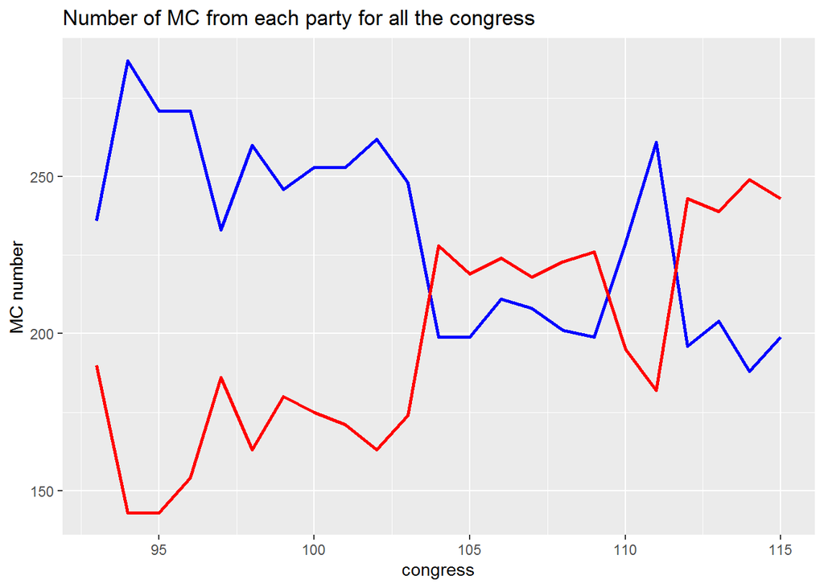